# My Spotify Data - 2022

Sam Freis

2023-01-17

## Analyzing and visualizing my own Spotify history from January 2022 - January 2023

#### Data Import

```r
# read in stream history
stream <- fromJSON("StreamingHistory0.json", flatten = TRUE)
```

#### Brief Data Examination of Data Structure

```r
# look at var names and info
names(stream)
```

```
## [1] "endTime"    "artistName" "trackName"  "msPlayed"
```

```r
str(stream)
```

```
## 'data.frame':    10000 obs. of  4 variables:
##  $ endTime   : chr  "2022-01-11 00:01" "2022-01-11 02:48" "2022-01-11 15:07" "2022-01-11 15:10" ...
##  $ artistName: chr  "Liz Phair" "Peaches" "Florist" "Indigo De Souza" ...
##  $ trackName : chr  "Supernova" "Kick It" "Shadow Bloom" "Pretty Pictures" ...
##  $ msPlayed  : int  168840 29097 0 178236 188586 277142 269923 48901 225632 139674 ...
```

```r
head(stream)
```

```
##            endTime      artistName       trackName msPlayed
## 1 2022-01-11 00:01       Liz Phair       Supernova   168840
## 2 2022-01-11 02:48         Peaches         Kick It    29097
## 3 2022-01-11 15:07         Florist    Shadow Bloom        0
## 4 2022-01-11 15:10 Indigo De Souza Pretty Pictures   178236
## 5 2022-01-11 15:13       Half Waif         Swimmer   188586
## 6 2022-01-11 15:32       girlhouse      concussion   277142
```

```r
# add date and time
spotify <- stream %>%
  as_tibble() %>%
  mutate_at("endTime", ymd_hm) %>%
  mutate(endTime = endTime - hours(6)) %>%
  mutate(date = floor_date(endTime, "day") %>% as_date, seconds = msPlayed / 1000, minutes = seconds / 60)
```

## Research Questions:

### 1. Which artists did I listen to most?

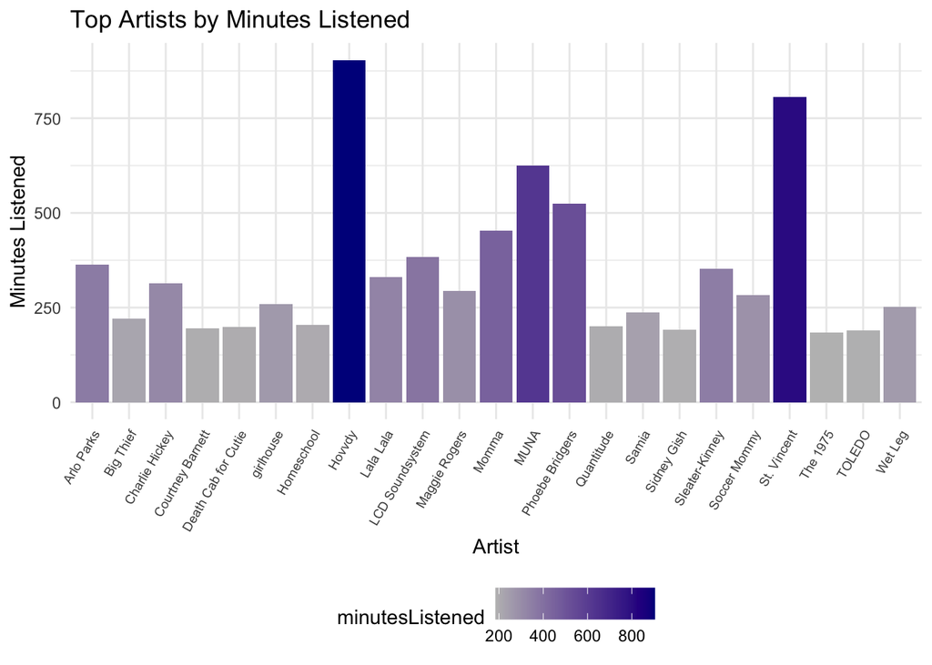

```r
p1 <- spotify %>%
  filter(date >= "2022-01-01") %>%
  group_by(artistName) %>%
  summarize(minutesListened = sum(minutes)) %>%
  filter(minutesListened >= 180) %>%
  ggplot(aes(x = artistName, y = minutesListened)) +
  geom_col(aes(fill = minutesListened)) +
  scale_fill_gradient(low = "grey", high = "darkblue") +
  labs(x= "Artist", y= "Minutes Listened") +
  ggtitle("Top Artists by Minutes Listened") +
  theme_minimal()+
  theme(legend.position = "bottom", axis.text.x = element_text(angle=60, size=7, hjust = 1))
p1
```

```r
# activity by artist
p2 <- spotify %>%
  group_by(artistName, date = floor_date(date, "month")) %>%
  summarize(hours = sum(minutes) / 60) %>%
  ggplot(aes(x = date, y = hours, group = artistName)) +
  labs(x= "Date", y= "Hours of Listen Time") +
  ggtitle("Listening Activity by Artist Over Time") +
  geom_line() +
  gghighlight(artistName == "St. Vincent" || artistName == "Hovvdy")+
  theme_minimal()
```

```
## label_key: artistName
```

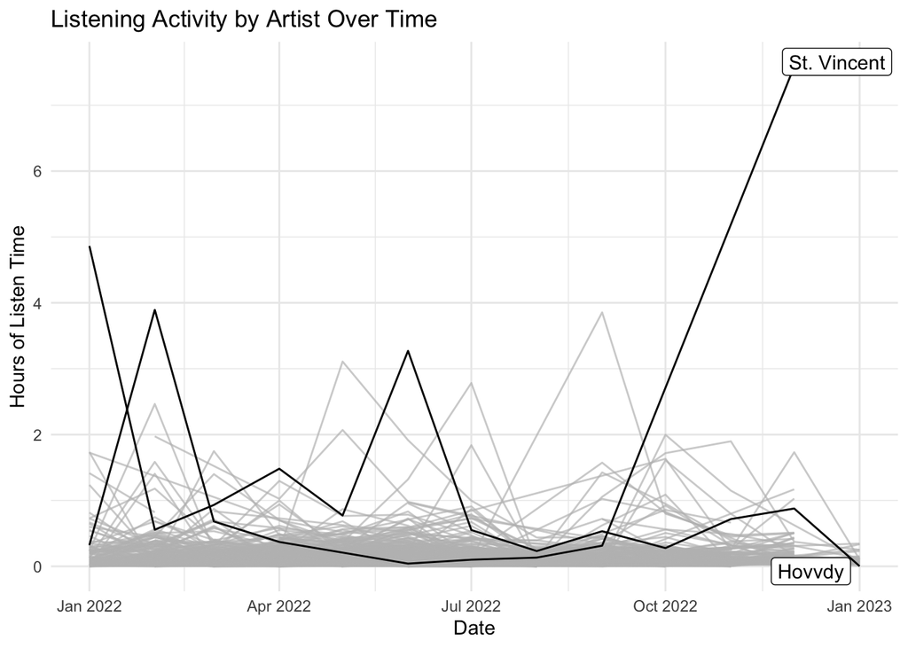

```r
p2
```

My top artists in this time frame were both Texans, of course. I listened to Hovvdy and St. Vincent for 750+ minutes last year. My Hovvdy listening peaked right after they released a new album and right around when I saw them live. My St. Vincent listening was high at the start of 2022, around when I got to see her in concert, and then my listening took off again in late 2022. I tend to listen to music I know well when working on analyses and writing. So, St. Vincent’s discography has been playing on repeat while I worked on projects with deadlines at the end of 2022. Also, shout out to the Quantitude Pod for making the 3+ hours of listening time cut.

### 2. Which songs did I listen to most?

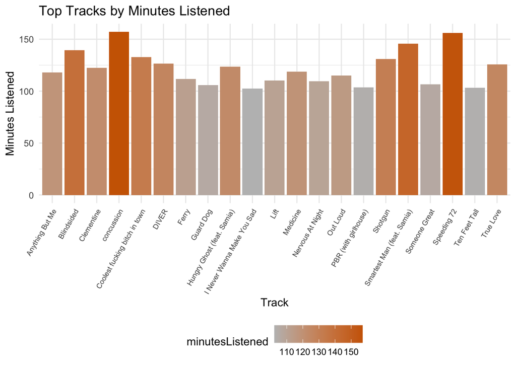

```r
p3<-spotify %>%
  filter(date >= "2022-01-01") %>%
  group_by(trackName) %>%
  summarize(minutesListened = sum(minutes)) %>%
  filter(minutesListened >= 100) %>%
  ggplot(aes(x = trackName, y = minutesListened)) +
  geom_col(aes(fill = minutesListened)) +
  scale_fill_gradient(low = "grey", high = "darkorange3") +
  labs(x= "Track", y= "Minutes Listened") +
  ggtitle("Top Tracks by Minutes Listened") +
  theme_minimal()+
  theme(legend.position = "bottom", axis.text.x = element_text(angle=60, size=7, hjust = 1))
p3
```

Songs I listened to for over 100 minutes in this time frame. My top songs were concussion by girlhouse and Speeding 72 by Momma.

### 3. Looking at time-related data

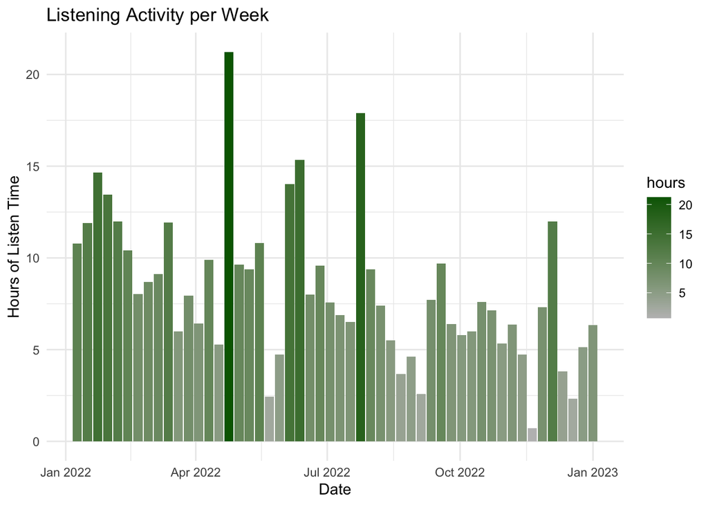

```r
# activity per week and hour
p4 <- spotify %>%
  filter(date >= "2022-01-01") %>%
  group_by(date) %>%
  group_by(date = floor_date(date, "week")) %>%
  summarize(hours = sum(minutes) / 60) %>%
  arrange(date) %>%
  ggplot(aes(x = date, y = hours)) +
  geom_col(aes(fill = hours)) +
  scale_fill_gradient(low = "grey", high = "darkgreen") +
  labs(x= "Date", y= "Hours of Listen Time") +
  ggtitle("Listening Activity per Week")+
  theme_minimal()
p4
```

```r
# activity by time of day
day <- spotify %>%
  filter(date >= "2022-01-01") %>%
  group_by(date, hour = hour(endTime), weekday = wday(date, label = TRUE))%>%
  summarize(minutesListened = sum(minutes))
```

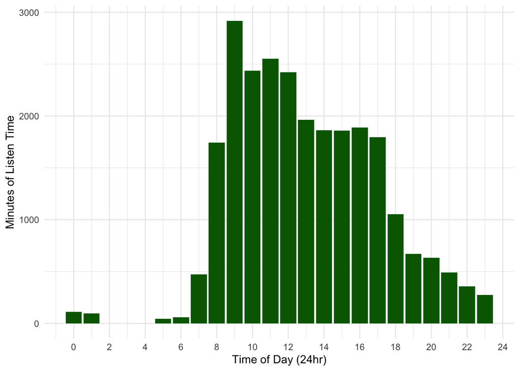

```r
p5<-day %>%
  ggplot(aes(x = hour, y = minutesListened, group = date)) +
  geom_col(fill = "darkgreen") +
  labs(x= "Time of Day (24hr)", y= "Minutes of Listen Time")+
  scale_x_continuous(breaks = seq(0, 24, by = 2))+
  theme_minimal()
p5
```

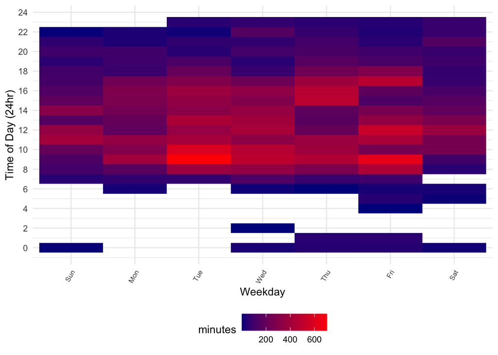

```r
# activity by day
p6 <-day %>%
  group_by(weekday, hour) %>%
  summarize(minutes = sum(minutesListened)) %>%
  ggplot(aes(x = weekday, hour, fill = minutes)) +
  geom_tile() +
  scale_fill_gradient(low = "darkblue", high = "red") +
  labs(x= "Weekday", y= "Time of Day (24hr)")+
  scale_y_continuous(breaks = seq(0, 24, by = 2))+
  theme_minimal()+
  theme(legend.position = "bottom", axis.text.x = element_text(angle=60, size=7, hjust = 1))
p6
```

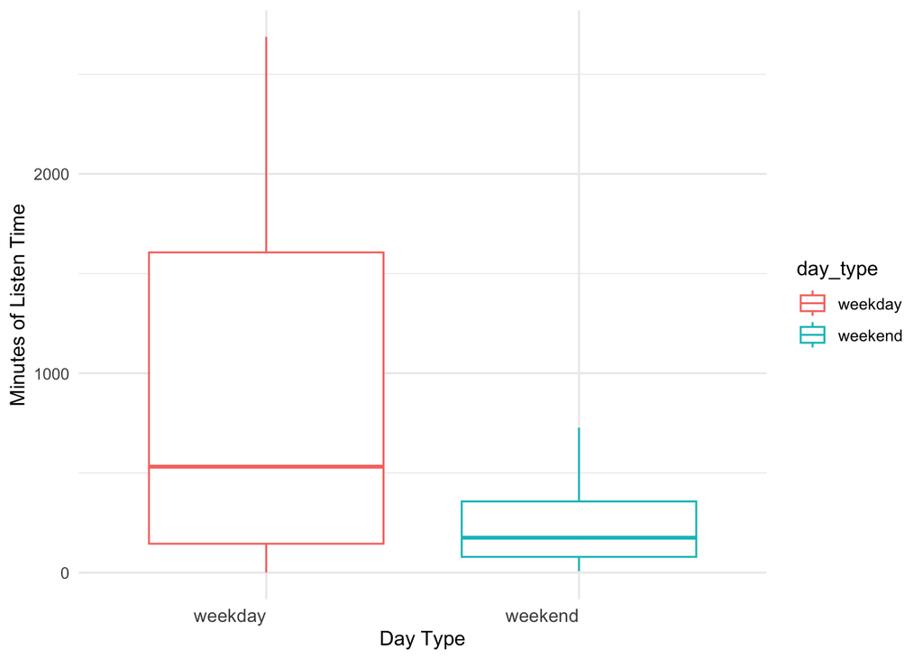

```r
# activity weekdays v weekends
p7 <- day %>%
  mutate(day_type = if_else(weekday %in% c("Sat", "Sun"), "weekend", "weekday")) %>%
  group_by(day_type, hour) %>%
  summarize(minutes = sum(minutesListened)) %>%
  ggplot(aes(x = day_type, y = minutes, color = day_type)) +
  geom_boxplot()+
  labs(x= "Day Type", y= "Minutes of Listen Time") +
theme_minimal()+
  theme(axis.text.x = element_text(size=10, hjust = 1))
p7
```

I listened to a lot music in between April of 2022 and August of 2022. I drove to Texas from Colorado and back that summer, so these trends make sense. My listening time typically peaks on weekday mornings.